# BelkinElago data

Ashiqur

10/9/2019

## BelkinElago data exploratory analysis

Data set has been given by Danielle Sherman and the exploratory Analysis is shown below :

#### load data set

```r
Belkin<-read.csv2("BelkinElagoComplete.csv")
```

#### Summary Function

summary function gives us the min, max, mean, median, and quartiles of each attribute

```r
summary(Belkin)
```

```
##      salary            age            elevel           car
##  Min.   : 20000   Min.   :20.00   Min.   :1.000   Min.   : 1.00
##  1st Qu.: 52109   1st Qu.:35.00   1st Qu.:2.000   1st Qu.: 5.00
##  Median : 84969   Median :50.00   Median :2.000   Median :10.00
##  Mean   : 84897   Mean   :49.81   Mean   :2.339   Mean   :10.47
##  3rd Qu.:117168   3rd Qu.:65.00   3rd Qu.:3.000   3rd Qu.:16.00
##  Max.   :150000   Max.   :80.00   Max.   :4.000   Max.   :20.00
##     zipcode          credit         brand
##  Min.   :0.000   Min.   :416.6   Belkin:4652
##  1st Qu.:2.000   1st Qu.:563.4   Elago :5348
##  Median :4.000   Median :632.1
##  Mean   :4.037   Mean   :632.1
##  3rd Qu.:6.000   3rd Qu.:701.3
##  Max.   :8.000   Max.   :849.0
```

```r
#hist(Belkin$age)
#plot(Belkin$age,Belkin$elevel)#
#cor(Belkin$age,Belkin$car)
```

#### Head of the data set

```r
head(Belkin)
```

```
##     salary age elevel car zipcode credit brand
## 1 123476.6  23      4   1       0 779.56 Elago
## 2 120274.6  22      4   1       2 784.70 Elago
## 3 121735.5  26      4   1       1 749.35 Elago
## 4 138276.8  23      4   1       0 743.85 Elago
## 5 126869.2  23      4   1       0 759.03 Elago
## 6 130595.1  22      4   1       7 774.13 Elago
```

#### df_status()

gives information on the structure of the dataframe and the data which contains variable names and data types,missing value and so on.one of the first steps, when we get a new dataset to analyze

```r
#library(DataExplorer)
library(funModeling)
```

```r
#plot_str(Belkin)//// Output doesn't show in the html file
df_status(Belkin)
```

```
##   variable q_zeros p_zeros q_na p_na q_inf p_inf    type unique
## 1   salary       0    0.00    0    0     0     0 numeric   9757
## 2      age       0    0.00    0    0     0     0 integer     61
## 3   elevel       0    0.00    0    0     0     0 integer      4
## 4      car       0    0.00    0    0     0     0 integer     20
## 5  zipcode    1097   10.97    0    0     0     0 integer      9
## 6   credit       0    0.00    0    0     0     0 numeric   8651
## 7    brand       0    0.00    0    0     0     0  factor      2
```

Zipcode cannot be Zero that must be chatagorical value.unique value shows that “elavel” has only 4 value so it can also be a chatagorical value

#### Changing the Data type

- q_zeros: quantity of zeros (p_zeros: in percent)
- q_inf: quantity of infinite values (p_inf: in percent)
- q_na: quantity of NA (p_na: in percent)
- type: factor or numeric
- unique: quantity of unique values

#### Histogram of salary,age,credit(used for one continuous value)

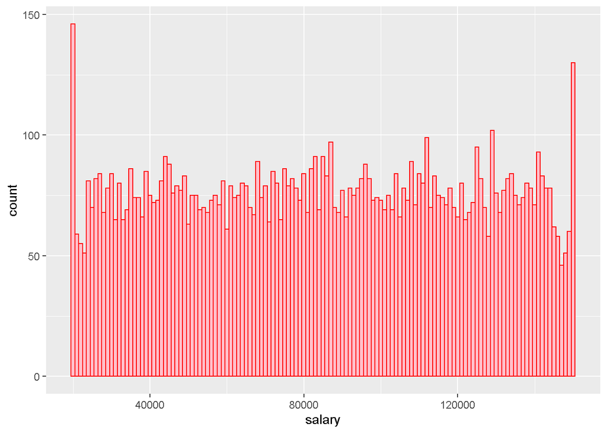

```r
library(ggplot2)
#salary
salary_his <- ggplot(Belkin,aes(x=salary))
salary_his + geom_histogram(binwidth=1000,color='red',fill='pink')
```

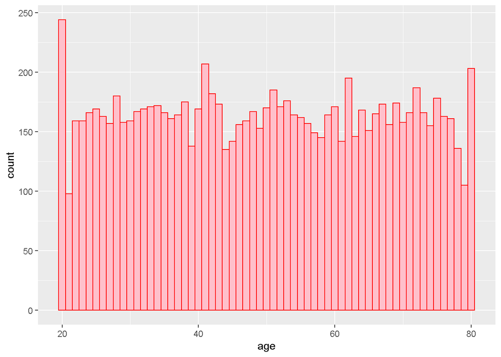

```r
#age
age_his <- ggplot(Belkin,aes(x=age))
age_his + geom_histogram(binwidth=1,color='red',fill='pink')
```

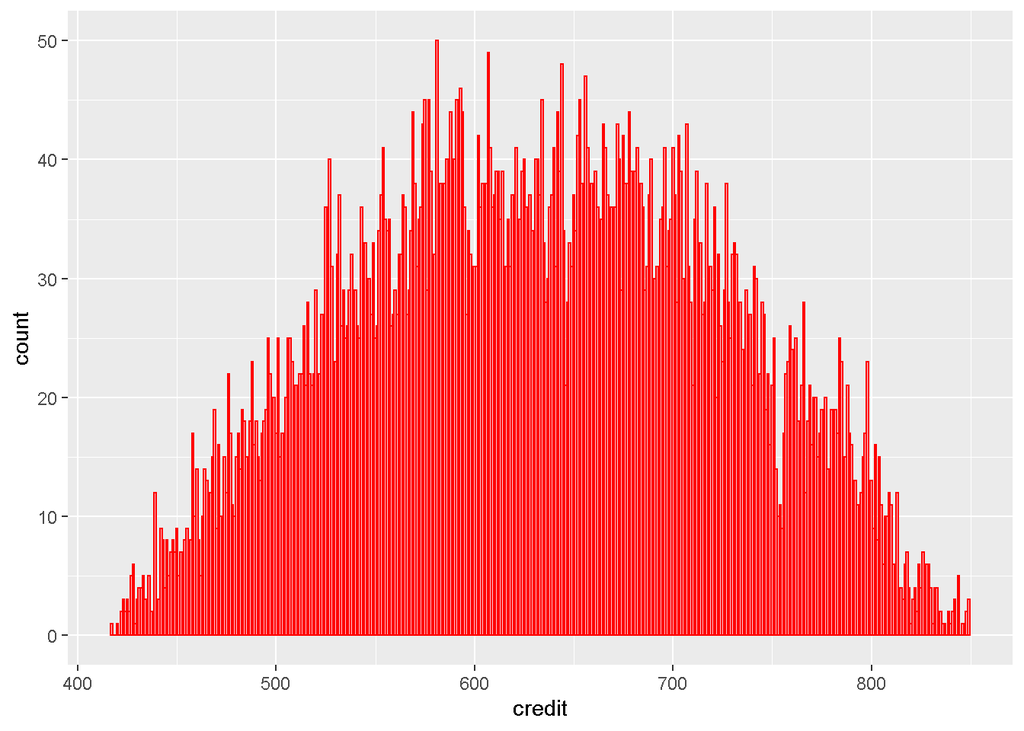

```r
#credit
credit_his <- ggplot(Belkin,aes(x=credit))
credit_his + geom_histogram(binwidth=1,color='red',fill='pink')
```

salary,age data is not normaly distributed but credit data is normaly distributed

#### Barplots (used for one continuous variable)

```r
library(ggplot2)
## counts (or sums of weights)
belkin_bar<- ggplot(Belkin, aes(elevel))
# Number of people in each education level:
#belkin_bar + geom_bar(color="red",fill="black")
```

Average educated people is more then the high or low educated people it make sense.

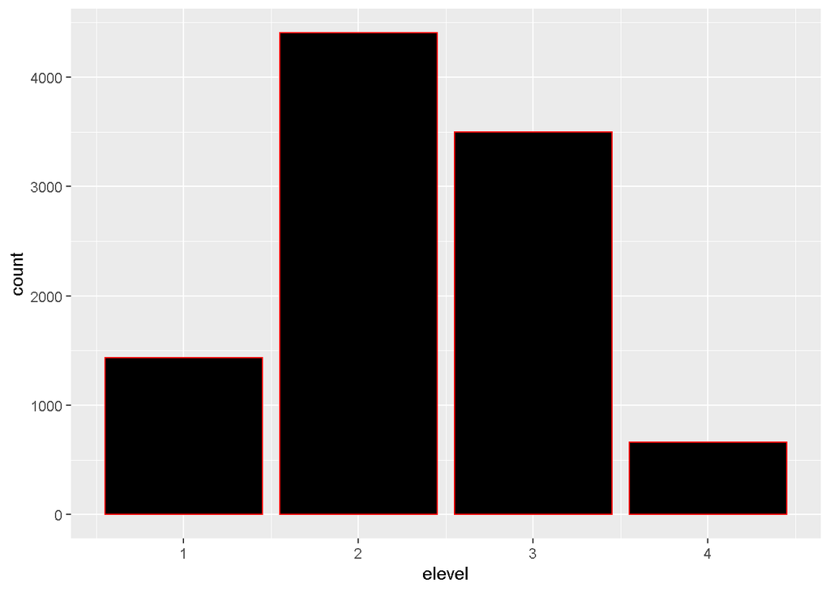

```r
Belkin$elevel<-as.factor(Belkin$elevel)
belkin_bar + geom_bar(color="red",fill="black")
```

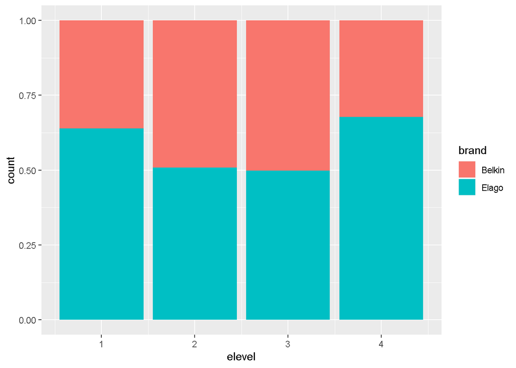

```r
#belkin_bar + geom_bar(aes(fill = elevel))#color seperated by elevel
belkin_bar + geom_bar(aes(fill = brand),position = "fill")#color seperated by brand
```

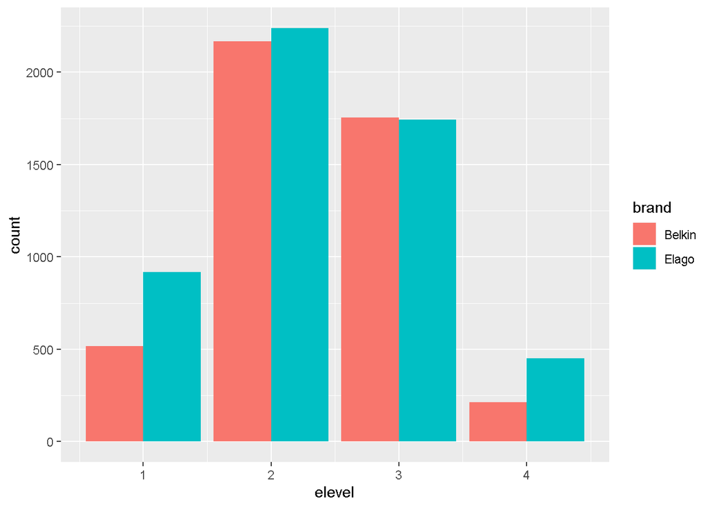

```r
belkin_bar + geom_bar(aes(fill = brand),position = "dodge")#color seperated by brand in two bar
```

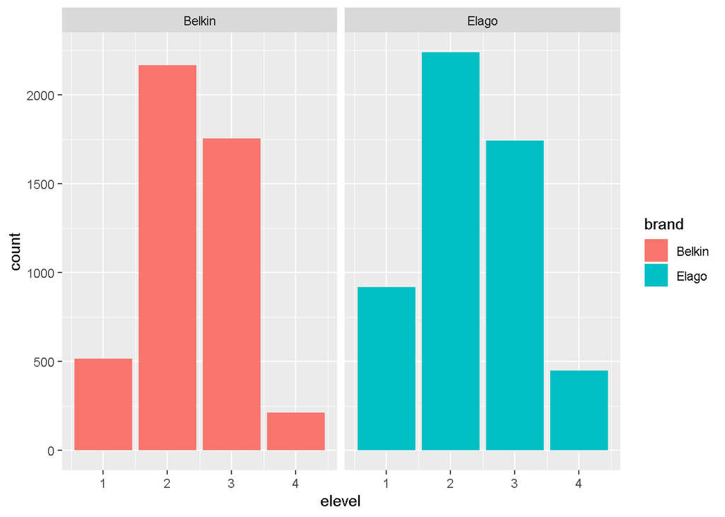

```r
belkin_bar + geom_bar(aes(fill = brand),position = "dodge")+facet_grid(. ~ brand)
```

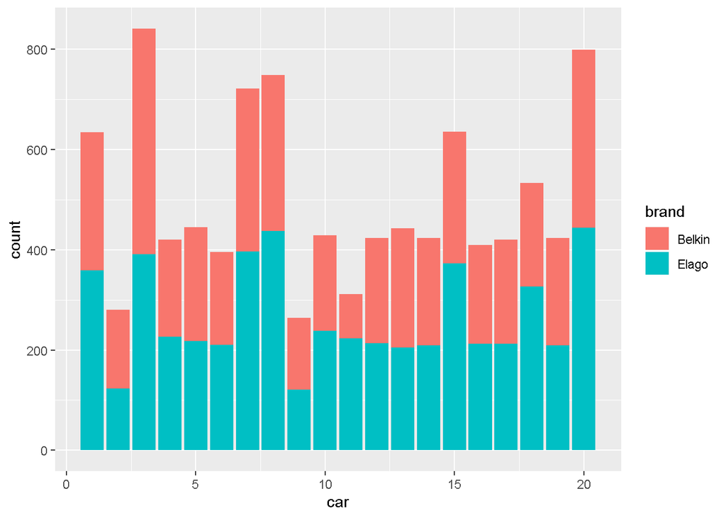

```r
#-------------------------------------car bar plot--------------------#
belkin_bar<- ggplot(Belkin, aes(car))
belkin_bar + geom_bar(aes(fill = brand))#color seperated by brand
```

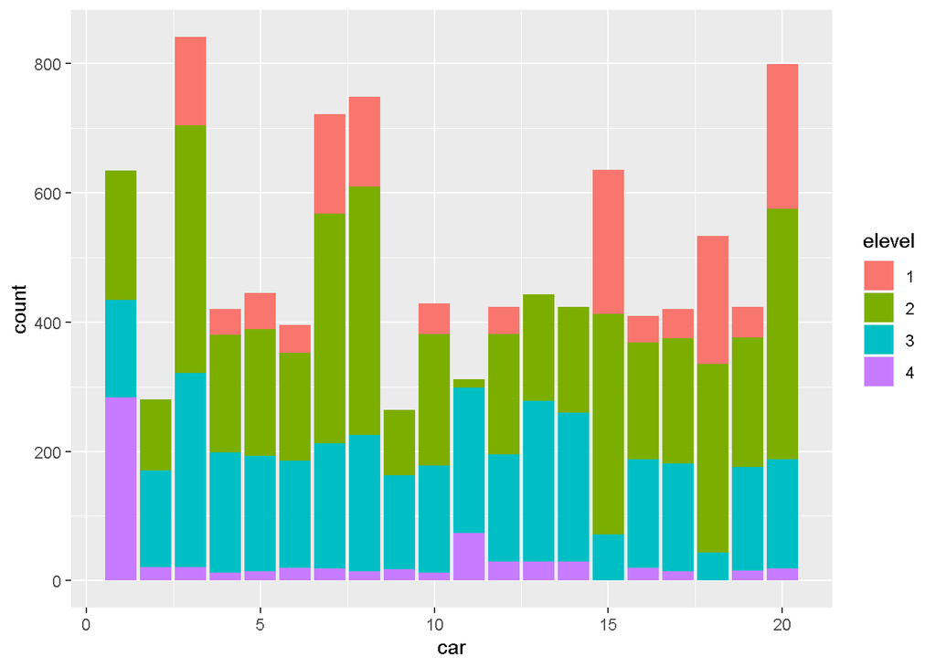

```r
belkin_bar + geom_bar(aes(fill = elevel))#color seperated by elevel
```

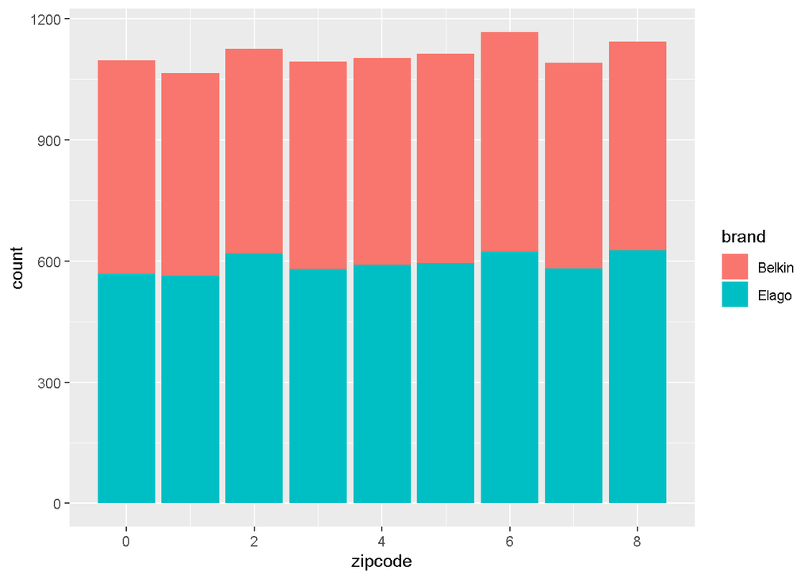

```r
#-------------------------------------Zipcode bar plot--------------------#
belkin_bar<- ggplot(Belkin, aes(zipcode))

belkin_bar + geom_bar(aes(fill = brand))#color seperated by brand
```

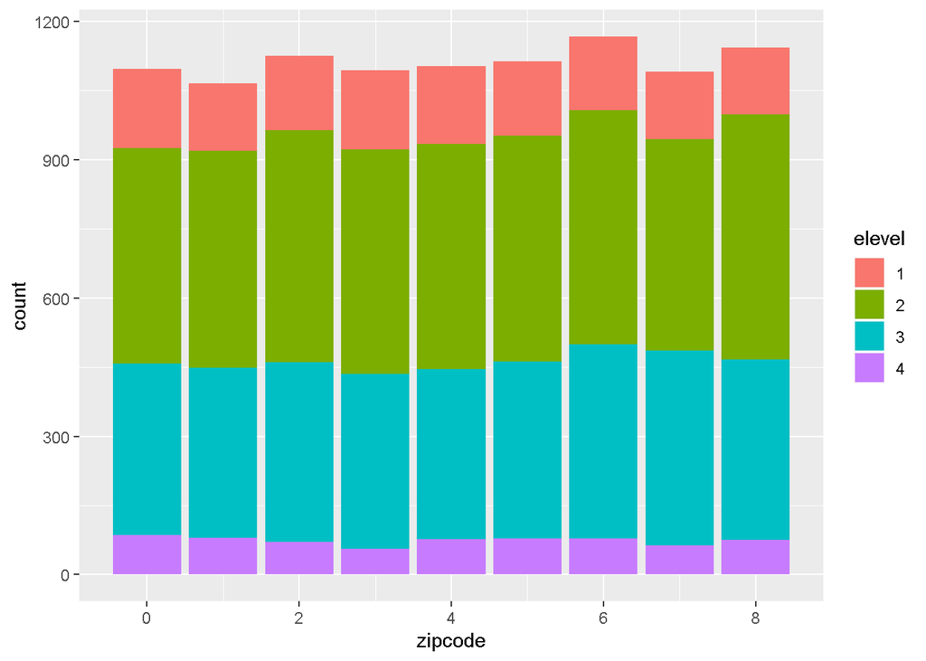

```r
belkin_bar + geom_bar(aes(fill = elevel))#color seperated by elevel
```

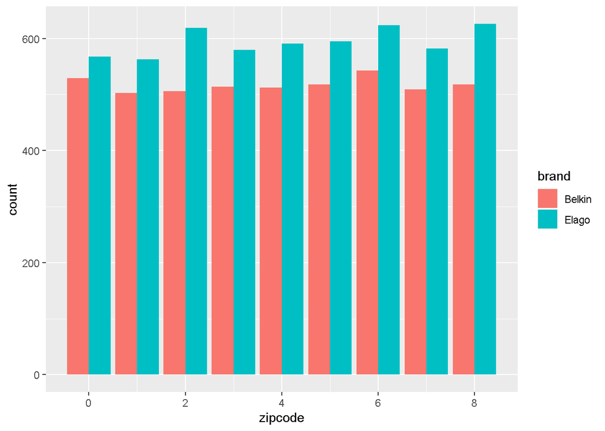

```r
belkin_bar + geom_bar(aes(fill = brand),position = "dodge")#color seperated by brand in two bar
```

### Scatterplots(used for two continuous)

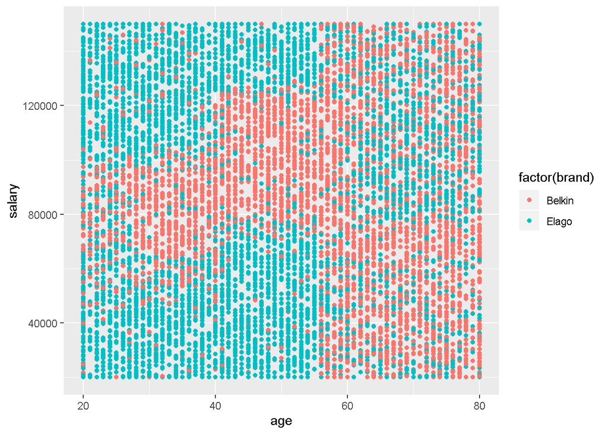

```r
#----------------------------------------salary vs age------------------------#
library(ggplot2)
belkin_scatt <- ggplot(data=Belkin,aes(x = age,y=salary))
belkin_scatt  + geom_point(aes(color=factor(brand)))#color seperated by brand
```

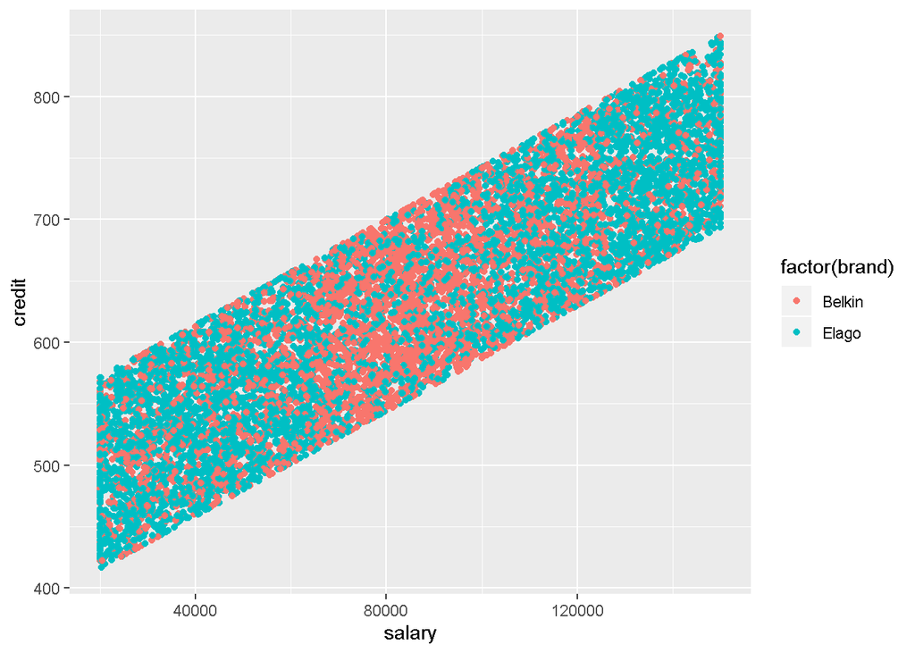

```r
#------------------------------------salary vs credit----------------------------
library(ggplot2)
belkin_scatt <- ggplot(data=Belkin,aes(x = salary,y=credit))
belkin_scatt  + geom_point(aes(color=factor(brand)))#color seperated by brand
```

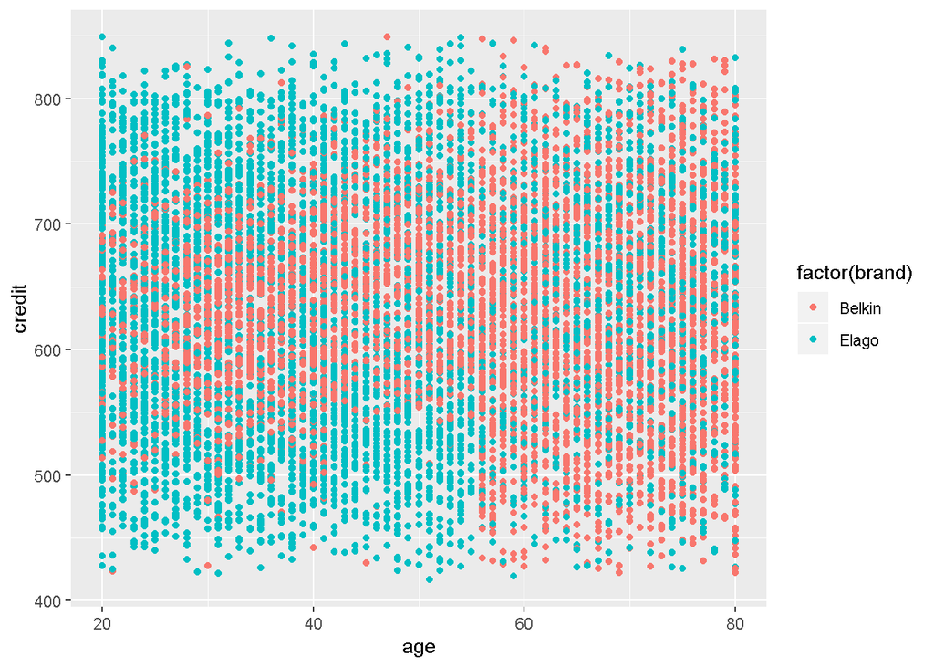

```r
#------------------------------------age vs credit----------------------------
library(ggplot2)
belkin_scatt <- ggplot(data=Belkin,aes(x = age,y=credit))
belkin_scatt  + geom_point(aes(color=factor(brand)))#color seperated by brand
```

#### Boxplot(used for discrete x and continuous y)

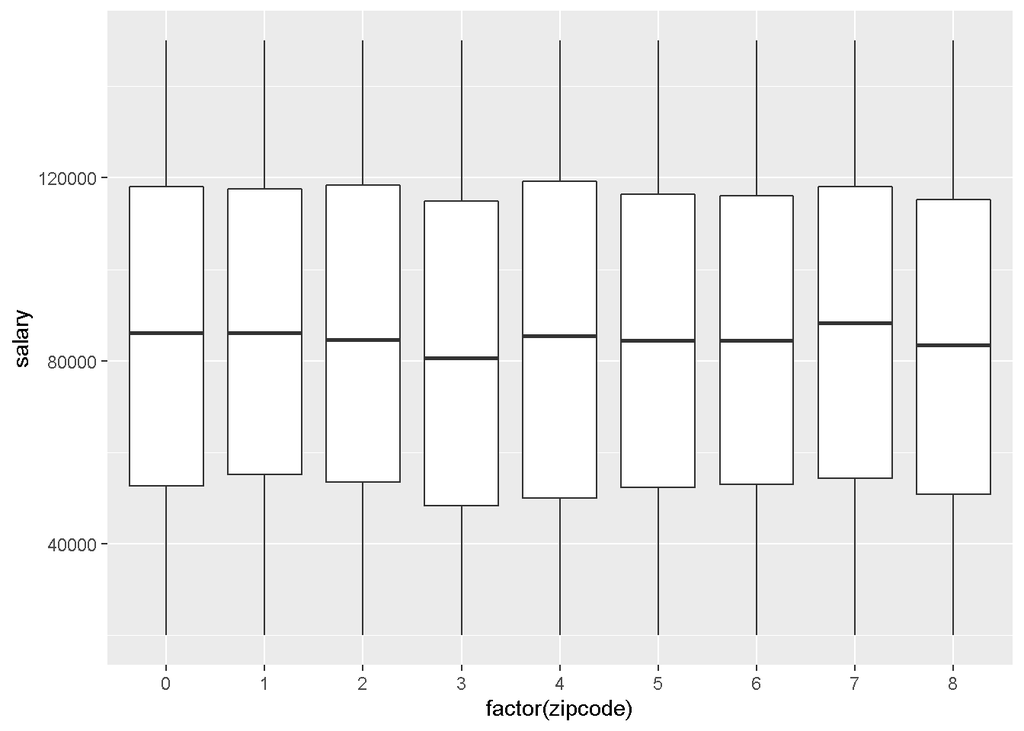

```r
library(ggplot2)
#----------------------------------------zipcode vs salary------------------------#

belkin_box <- ggplot(data=Belkin,aes(x = factor(zipcode),y=salary))
belkin_box  + geom_boxplot()
```

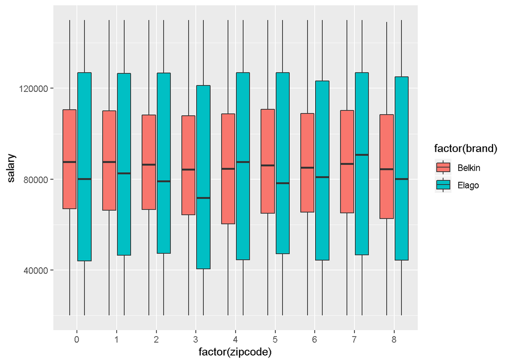

```r
belkin_box  + geom_boxplot(aes(fill = factor(brand)))#color seperated by brand
```

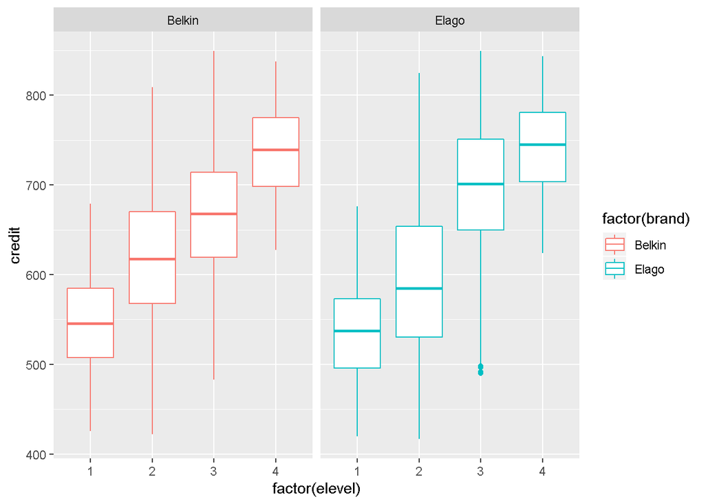

```r
#------------------------------------zipcode vs credit----------------------------

belkin_box <- ggplot(data=Belkin,aes(x = factor(elevel),y=credit))
belkin_box  + geom_boxplot(aes(color=factor(brand)))+facet_grid(. ~ brand)#color seperated by brand
```

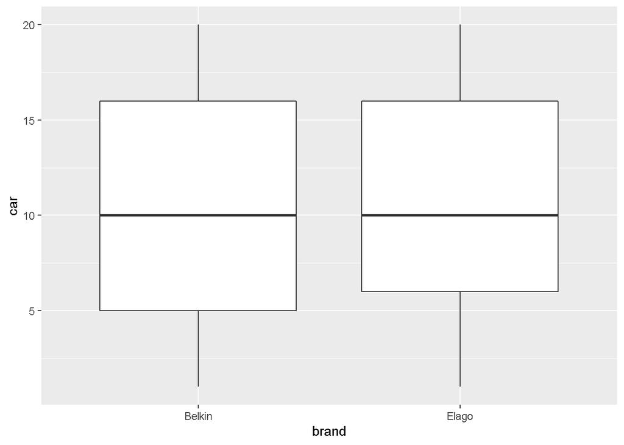

```r
#------------------------------------age vs credit----------------------------

belkin_box <- ggplot(data=Belkin,aes(x = brand,y=car))
belkin_box  + geom_boxplot()#this graph does not mean anything
```

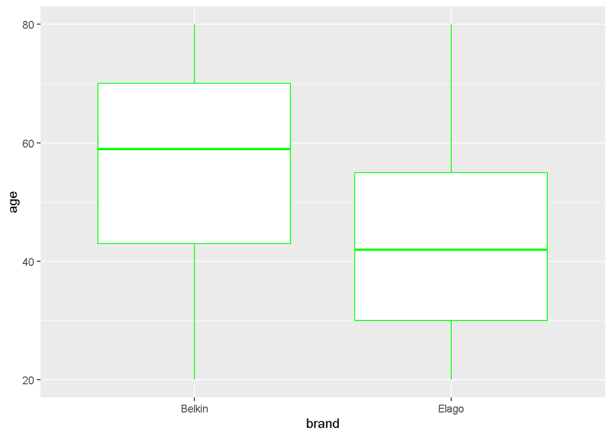

```r
#-------------------------------------age vs brand----------------------------------#
belkin_box <- ggplot(data=Belkin,aes(x = brand,y=age))
belkin_box  + geom_boxplot(color="green")
```

#### 2d Hex Plot

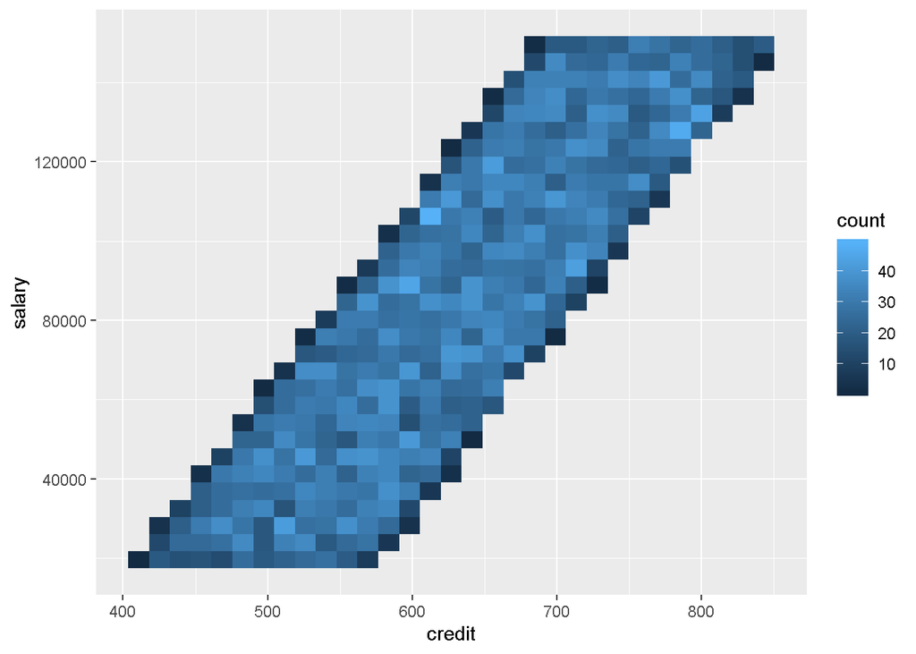

```r
library(ggplot2)
belkin_hex <- ggplot(data=Belkin,aes(x = credit,y=salary))
belkin_hex + geom_bin2d()
```

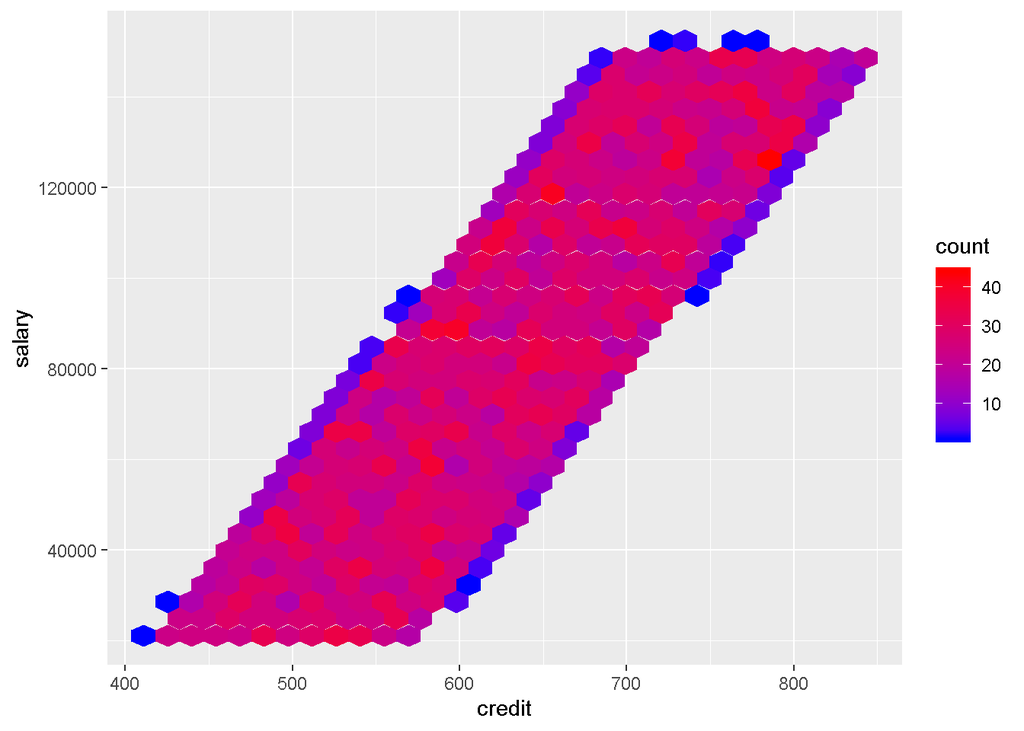

```r
belkin_hex + geom_hex() + scale_fill_gradient(high='red',low='blue')
```

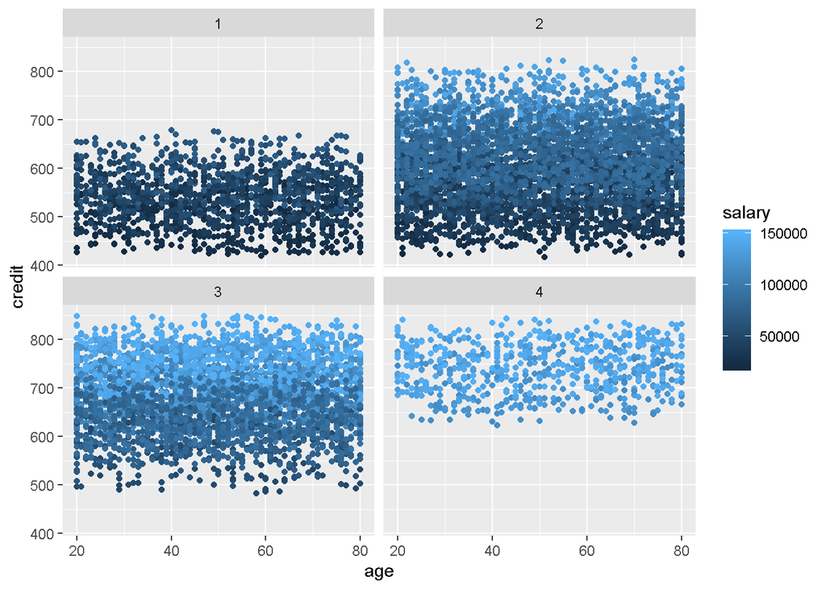

```r
#----------------------Explaining patterns in credit status------------
ggplot(Belkin, mapping = aes(x=age,y=credit)) +
  geom_point(aes(color = salary)) + facet_wrap(~elevel)
```

educated people are earning more mony which make sense ## used funModeling library for exploring data

#### Analyzing categorical variables

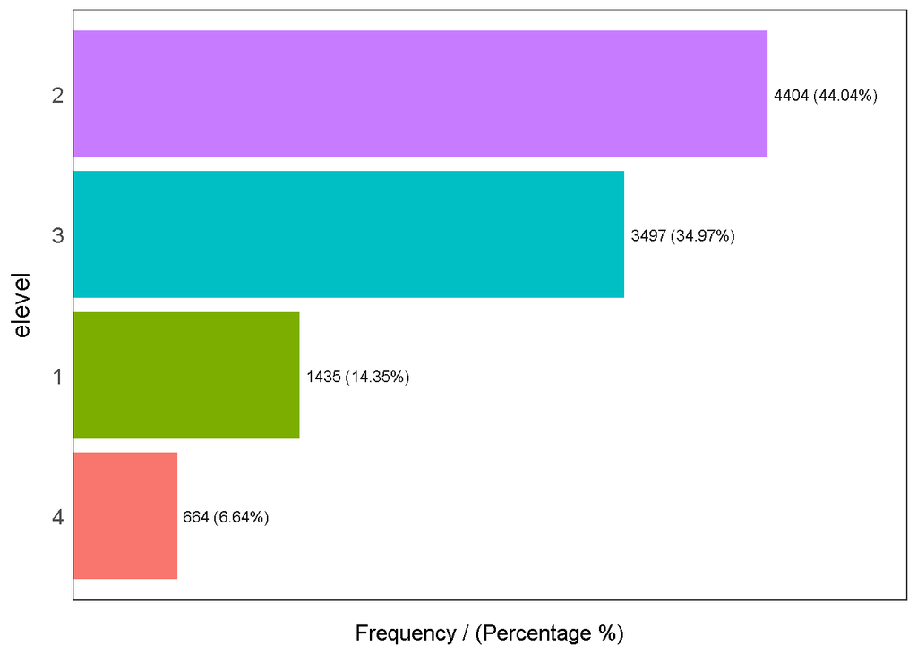

```
##   elevel frequency percentage cumulative_perc
## 1      2      4404      44.04           44.04
## 2      3      3497      34.97           79.01
## 3      1      1435      14.35           93.36
## 4      4       664       6.64          100.00
```

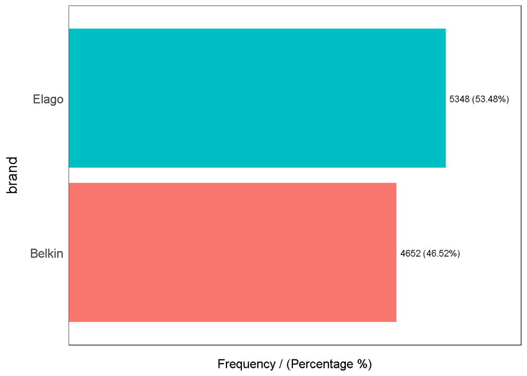

```
##    brand frequency percentage cumulative_perc
## 1  Elago      5348      53.48           53.48
## 2 Belkin      4652      46.52          100.00
```

```
## [1] "Variables processed: elevel, brand"
```

```r
freq(Belkin)
```

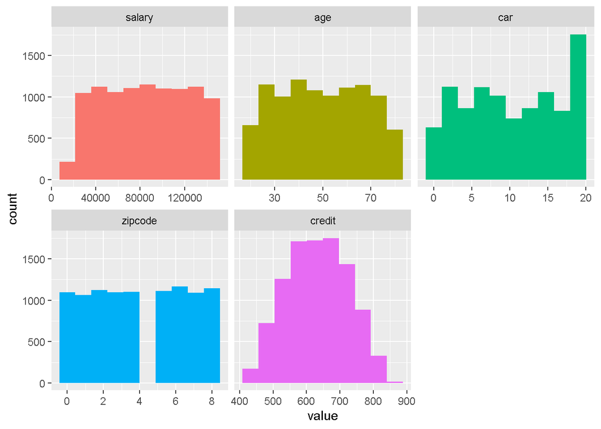

```r
 plot_num(Belkin)
```

```r
profiling_num(Belkin)
```

```
##   variable       mean      std_dev variation_coef       p_01      p_05
## 1   salary 84897.2509 37709.806791      0.4441817 20000.0000 25921.608
## 2      age    49.8115    17.596322      0.3532582    20.0000    22.000
## 3      car    10.4728     6.023661      0.5751719     1.0000     1.000
## 4  zipcode     4.0366     2.581420      0.6395034     0.0000     0.000
## 5   credit   632.0648    91.371581      0.1445605   445.4995   482.457
##         p_25     p_50        p_75        p_95       p_99     skewness
## 1 52109.2827 84968.94 117168.2605 143297.0010 150000.000 -0.006945249
## 2    35.0000    50.00     65.0000     77.0000     80.000  0.008270035
## 3     5.0000    10.00     16.0000     20.0000     20.000  0.058502642
## 4     2.0000     4.00      6.0000      8.0000      8.000 -0.019062007
## 5   563.3825   632.07    701.2975    783.5315    815.005  0.002483984
##   kurtosis       iqr            range_98                     range_80
## 1 1.814148 65058.978     [20000, 150000] [32480.123939, 137027.67826]
## 2 1.800191    30.000            [20, 80]                     [26, 74]
## 3 1.718976    11.000             [1, 20]                      [3, 19]
## 4 1.773200     4.000              [0, 8]                       [0, 8]
## 5 2.235649   137.915 [445.4995, 815.005]           [508.999, 757.386]
```

The average number of car for each person is 10 which make no sense so this number must indicate the brand name

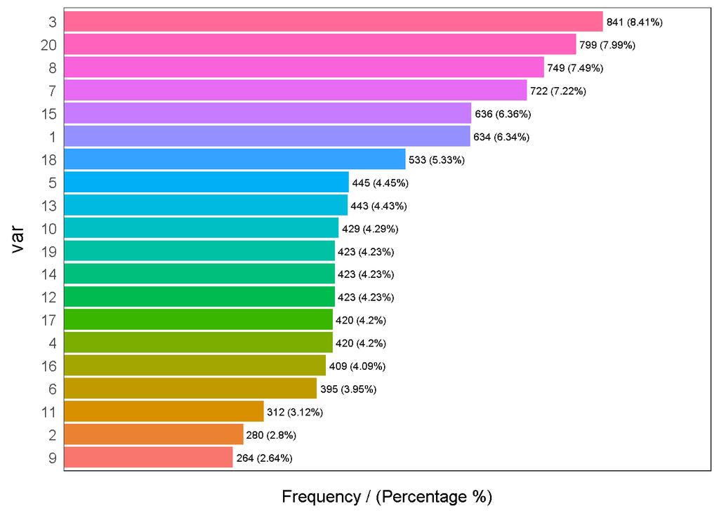

```
##    var frequency percentage cumulative_perc
## 1    3       841       8.41            8.41
## 2   20       799       7.99           16.40
## 3    8       749       7.49           23.89
## 4    7       722       7.22           31.11
## 5   15       636       6.36           37.47
## 6    1       634       6.34           43.81
## 7   18       533       5.33           49.14
## 8    5       445       4.45           53.59
## 9   13       443       4.43           58.02
## 10  10       429       4.29           62.31
## 11  12       423       4.23           66.54
## 12  14       423       4.23           70.77
## 13  19       423       4.23           75.00
## 14   4       420       4.20           79.20
## 15  17       420       4.20           83.40
## 16  16       409       4.09           87.49
## 17   6       395       3.95           91.44
## 18  11       312       3.12           94.56
## 19   2       280       2.80           97.36
## 20   9       264       2.64          100.00
```

```r
Belkin$car <- as.factor(Belkin$car)
freq(Belkin$car)
```

#### correlation between the Attribute

```r
correlation_table(data=Belkin,target="brand")
```

```
##   Variable brand
## 1    brand  1.00
## 2  zipcode  0.01
## 3   salary -0.02
## 4   credit -0.02
## 5      age -0.35
```

```r
correlation_table(data=Belkin,target="zipcode")
```

```
##   Variable zipcode
## 1  zipcode    1.00
## 2      age    0.00
## 3   credit    0.00
## 4   salary   -0.01
```

```r
correlation_table(data=Belkin,target="age")
```

```
##   Variable  age
## 1      age 1.00
## 2   salary 0.01
## 3  zipcode 0.00
## 4   credit 0.00
```

```r
correlation_table(data=Belkin,target="car")
```

```
##   Variable   car
## 1      car  1.00
## 2      age  0.01
## 3  zipcode  0.00
## 4   credit -0.23
## 5   salary -0.24
```

```r
correlation_table(data=Belkin,target="salary")
```

```
##   Variable salary
## 1   salary   1.00
## 2   credit   0.87
## 3      age   0.01
## 4  zipcode  -0.01
```

```r
correlation_table(data=Belkin,target="credit")
```

```
##   Variable credit
## 1   credit   1.00
## 2   salary   0.87
## 3      age   0.00
## 4  zipcode   0.00
```